# Data Analysis in R

For most applied research, conducting data analysis in R involves the following core tasks:

1. *Importing* different types of data from different sources
2. *Summarizing* the structure and content of data
3. Carrying out operations and calculations across *groups*
4. *Reshaping* data to and from various formats
5. Attempting to conduct *causal inference*

### Importing data/spreadsheets

For spreadsheet data that **is not** explicitly saved as a Microsoft Excel file:

```r
# Import data with header row, values separated by ",", decimals as "."
mydataset<-read.csv(file="  ", stringsAsFactors=) # Basic Call
```

```r
# Example
air<-read.csv(file="data/airline_small.csv", stringsAsFactors=F)
dim(air) # Check dimensionality of dataset
```

```
[1] 5000   29
```

```r
air[1:5, 1:5] # View first 5 rows/columns
```

```
  Year Month DayofMonth DayOfWeek DepTime
1 2005    11         22         2    1700
2 2008     1         31         4    2216
3 2005     7         17         7     905
4 2008     9         23         2     859
5 2005     3          5         6     827
```

```r
# Import data with header row, values separated by ";", decimals as ","
mydataset<-read.csv2(file="  ", stringsAsFactors=)

# Import data with header row, values separated by tab, decimals as "."
mydataset<-read.delim(file="  ", stringsAsFactors=)

# Import data with header row, values separated by tab, decimals as ";"
mydataset<-read.delim2(file="  ", stringsAsFactors=)

# For importing tabular data with maximum customizeability
mydataset<-read.table(file=, header=, sep=, quote=, dec=, fill=, stringsAsFactors=)
```

For spreadsheet data that **is** explicitly saved as a Microsoft Excel file (.xls or .xlsx):

```r
# Install the "XLConnect" package (only necessary one time)
# install.packages("XLConnect") # Not Run

# Load the "XLConnect" package (necessary every new R session)
library(XLConnect)
# For importing both .xls and .xlsx files
mydataset<-read.xls(xls=, sheet=) # Basic Call
```

```r
# Example with .xls (single sheet)
air<-loadWorkbook(file = "data/airline_small.xls")
air<-readWorksheet(object = air, sheet = 1)
air[1:5, 1:5]
```

```
  Year Month DayofMonth DayOfWeek DepTime
1 2005    11         22         2    1700
2 2008     1         31         4    2216
3 2005     7         17         7     905
4 2008     9         23         2     859
5 2005     3          5         6     827
```

```r
# Example with .xlsx (single sheet)
air<-loadWorkbook(file = "data/airline_small.xlsx")
air<-readWorksheet(object = air, sheet = 1)
air[1:5, 1:5]
```

```
  Year Month DayofMonth DayOfWeek DepTime
1 2005    11         22         2    1700
2 2008     1         31         4    2216
3 2005     7         17         7     905
4 2008     9         23         2     859
5 2005     3          5         6     827
```

### Importing data/proprietaries (e.g.: .dta, .spss, .ssd)

```r
# Install the "foreign" package (only necessary one time)
# install.packages("foreign") # Not Run

# Load the "foreign" package (necessary every new R session)
library(foreign)
```

```r
read.xxxx(file=) # Basic call, where .xxxx is the imported file's extension/client

# For importing Stata files
mydataset<-read.dta(file=)
```

```r
# Example
air<-read.dta(file="data/airline_small.dta")
air[1:5, 1:5]
```

```
  Year Month DayofMonth DayOfWeek DepTime
1 2005    11         22         2    1700
2 2008     1         31         4    2216
3 2005     7         17         7     905
4 2008     9         23         2     859
5 2005     3          5         6     827
```

```r
# For importing SPSS files
mydataset<-read.spss(file=)

# For importing SAS files
mydataset<-read.ssd(file=)
mydataset<-read.xport(file=)

# For importing Fortran files
mydataset<-read.fortran(file=)

# For importing DBF files
mydataset<-read.dbf(file=)
```

### Importing data/urls (e.g.: http, https, ftp)

```r
# Import dataset on different car characteristics
link<-"http://archive.ics.uci.edu/ml/machine-learning-databases/autos/imports-85.data"
cars<-read.csv(file = link, header = F)
cars[1:25, 1:5]
```

```
   V1  V2          V3  V4    V5
1   3   ? alfa-romero gas   std
2   3   ? alfa-romero gas   std
3   1   ? alfa-romero gas   std
4   2 164        audi gas   std
5   2 164        audi gas   std
6   2   ?        audi gas   std
7   1 158        audi gas   std
8   1   ?        audi gas   std
9   1 158        audi gas turbo
10  0   ?        audi gas turbo
11  2 192         bmw gas   std
12  0 192         bmw gas   std
13  0 188         bmw gas   std
14  0 188         bmw gas   std
15  1   ?         bmw gas   std
16  0   ?         bmw gas   std
17  0   ?         bmw gas   std
18  0   ?         bmw gas   std
19  2 121   chevrolet gas   std
20  1  98   chevrolet gas   std
21  0  81   chevrolet gas   std
22  1 118       dodge gas   std
23  1 118       dodge gas   std
24  1 118       dodge gas turbo
25  1 148       dodge gas   std
```

### Importing data/other (e.g.: html tables, html, xml, json)

Say we wanted to scrape a list of votes in the US Congress contained in an html table (like [this](http://clerk.house.gov/evs/2015/index.asp))

```r
# Install the "XML" package (only necessary one time)
# install.packages("XML") # Not Run

# Load the "XML" package (necessary every new R session)
library(XML)
```

```r
mydataset<-readHTMLTable(doc=, header=, which=, stringsAsFactors=) # Basic Call
```

```r
link<-"http://clerk.house.gov/evs/2015/index.asp"
votes.2015<-readHTMLTable(doc=link, header=T, which=1, stringsAsFactors=F)

dim(votes.2015) # Check data dimensionality
```

```
[1] 20  6
```

```r
colnames(votes.2015) # Get column names
```

```
[1] "Roll"              "Date"              "Issue"
[4] "Question"          "Result"            "Title/Description"
```

```r
votes.2015[1:10, 1:5]
```

```
   Roll   Date     Issue
1   489 29-Jul  H R 1994
2   488 29-Jul  H R 1994
3   487 29-Jul  H R 1994
4   486 29-Jul  H R 3236
5   485 29-Jul  H R 1300
6   484 29-Jul H RES 388
7   483 29-Jul H RES 388
8   482 28-Jul   H R 427
9   481 28-Jul   H R 427
10  480 28-Jul   H R 427
                                              Question Result
1                                           On Passage      P
2              On Motion to Recommit with Instructions      F
3                         On Agreeing to the Amendment      F
4                                           On Passage      P
5  On Motion to Suspend the Rules and Pass, as Amended      P
6                        On Agreeing to the Resolution      P
7                    On Ordering the Previous Question      P
8                                           On Passage      P
9              On Motion to Recommit with Instructions      F
10                        On Agreeing to the Amendment      F
```

### Summarizing data/object structure

```r
# Load data
air<-read.csv("data/airline_small.csv")
# Get the object class
class(air)
```

```
[1] "data.frame"
```

```r
# Get the object dimensionality
dim(air) # Note this is rows by columns
```

```
[1] 5000   29
```

```r
# Get the column names
colnames(air)
```

```
 [1] "Year"              "Month"             "DayofMonth"
 [4] "DayOfWeek"         "DepTime"           "CRSDepTime"
 [7] "ArrTime"           "CRSArrTime"        "UniqueCarrier"
[10] "FlightNum"         "TailNum"           "ActualElapsedTime"
[13] "CRSElapsedTime"    "AirTime"           "ArrDelay"
[16] "DepDelay"          "Origin"            "Dest"
[19] "Distance"          "TaxiIn"            "TaxiOut"
[22] "Cancelled"         "CancellationCode"  "Diverted"
[25] "CarrierDelay"      "WeatherDelay"      "NASDelay"
[28] "SecurityDelay"     "LateAircraftDelay"
```

```r
# Get the row names
rownames(air)[1:50] # Only the first 50 rows
```

```
 [1] "1"  "2"  "3"  "4"  "5"  "6"  "7"  "8"  "9"  "10" "11" "12" "13" "14"
[15] "15" "16" "17" "18" "19" "20" "21" "22" "23" "24" "25" "26" "27" "28"
[29] "29" "30" "31" "32" "33" "34" "35" "36" "37" "38" "39" "40" "41" "42"
[43] "43" "44" "45" "46" "47" "48" "49" "50"
```

```r
# View first six rows and all columns
head(air)
```

```
  Year Month DayofMonth DayOfWeek DepTime CRSDepTime ArrTime CRSArrTime
1 2005    11         22         2    1700       1700    1803       1800
2 2008     1         31         4    2216       2140     531        505
3 2005     7         17         7     905        910    1230       1240
4 2008     9         23         2     859        905    1121       1125
5 2005     3          5         6     827        830    1208       1200
6 2005    12         19         1    1321       1125    2207       2000
  UniqueCarrier FlightNum TailNum ActualElapsedTime CRSElapsedTime AirTime
1            OO      6234  N561SW                63             60      43
2            NW       346  N527US               255            265     227
3            F9       668  N803FR               145            150     122
4            AA        39  N5ETAA               322            320     300
5            HA        11  N587HA               341            330     193
6            UA       182  N567UA               346            335     318
  ArrDelay DepDelay Origin Dest Distance TaxiIn TaxiOut Cancelled
```

[output cut: 20 more lines]

```r
# View last six rows and all columns
tail(air)
```

```
     Year Month DayofMonth DayOfWeek DepTime CRSDepTime ArrTime CRSArrTime
4995 2006     3         24         5    2341       2345     537        535
4996 2006     3         16         4     909        915    1023       1035
4997 2005     8          3         3    1134       1130    1422       1416
4998 2005     7         17         7     837        840     945        946
4999 2007     5          4         5     733        730     901        900
5000 2007     7         22         7    2243       2200     712        621
     UniqueCarrier FlightNum TailNum ActualElapsedTime CRSElapsedTime
4995            TZ      4628  N317TZ               236            230
4996            OO      6244  N560SW                74             80
4997            UA       330  N451UA               108            106
4998            OO      6257  N284YV                68             66
4999            MQ      3165  N805AE                88             90
5000            US       942  N102UW               329            321
     AirTime ArrDelay DepDelay Origin Dest Distance TaxiIn TaxiOut
```

[output cut: 20 more lines]

```r
# Get detailed column-by-column information
str(air)
```

```
'data.frame':   5000 obs. of  29 variables:
 $ Year             : int  2005 2008 2005 2008 2005 2005 2005 2005 2007 2005 ...
 $ Month            : int  11 1 7 9 3 12 3 10 7 8 ...
 $ DayofMonth       : int  22 31 17 23 5 19 3 26 19 31 ...
 $ DayOfWeek        : int  2 4 7 2 6 1 4 3 4 3 ...
 $ DepTime          : int  1700 2216 905 859 827 1321 1751 1719 2235 1224 ...
 $ CRSDepTime       : int  1700 2140 910 905 830 1125 1755 1545 2225 1230 ...
 $ ArrTime          : int  1803 531 1230 1121 1208 2207 2118 1842 615 2001 ...
 $ CRSArrTime       : int  1800 505 1240 1125 1200 2000 2132 1715 607 2013 ...
 $ UniqueCarrier    : Factor w/ 20 levels "AA","AS","B6",..: 14 13 8 1 10 16 15 14 17 9 ...
 $ FlightNum        : int  6234 346 668 39 11 182 4517 6264 1485 44 ...
 $ TailNum          : Factor w/ 1802 levels "","0","000000",..: 943 870 1502 1101 1027 966 930 264 1329 37 ...
 $ ActualElapsedTime: int  63 255 145 322 341 346 327 83 280 277 ...
 $ CRSElapsedTime   : int  60 265 150 320 330 335 337 90 282 283 ...
 $ AirTime          : int  43 227 122 300 193 318 306 68 263 245 ...
 $ ArrDelay         : int  3 26 -10 -4 8 127 -14 87 8 -12 ...
 $ DepDelay         : int  0 36 -5 -6 -3 116 -4 94 10 -6 ...
 $ Origin           : Factor w/ 1 level "SFO": 1 1 1 1 1 1 1 1 1 1 ...
 $ Dest             : Factor w/ 66 levels "ABQ","ACV","ANC",..: 54 20 18 24 24 9 24 38 51 5 ...
 $ Distance         : int  199 2079 967 2398 2398 2704 2398 329 2254 2139 ...
 $ TaxiIn           : int  5 9 8 4 12 6 4 4 4 5 ...
 $ TaxiOut          : int  15 19 15 18 16 22 17 11 13 27 ...
 $ Cancelled        : int  0 0 0 0 0 0 0 0 0 0 ...
 $ CancellationCode : Factor w/ 4 levels "","A","B","C": 1 1 1 1 1 1 1 1 1 1 ...
 $ Diverted         : int  0 0 0 0 0 0 0 0 0 0 ...
 $ CarrierDelay     : int  0 4 0 NA 0 0 0 0 0 0 ...
 $ WeatherDelay     : int  0 0 0 NA 0 0 0 0 0 0 ...
 $ NASDelay         : int  0 0 0 NA 0 16 0 0 0 0 ...
 $ SecurityDelay    : int  0 0 0 NA 0 0 0 0 0 0 ...
 $ LateAircraftDelay: int  0 22 0 NA 0 111 0 87 0 0 ...
```

### Summarizing data/object content

A good place to start with our data is to calculate summary statistics. Note: these functions are sensitive to missing values (NA); you should be sure to specify `na.rm=T` to avoid errors.

```r
# Sample 100 times from the standard normal distribution
sample.data<-rnorm(n=100, mean=0, sd=1)
print(sample.data)
```

```
  [1]  0.06922303 -1.53932311  0.62908970  1.09528519  0.84220932
  [6] -0.07857193 -0.20089139 -0.24017939  0.98834497 -1.43306233
 [11] -0.38701720 -0.76114908 -0.42426790 -0.01579210  1.53371171
 [16]  0.72820840 -0.03394353  0.17721596 -0.08054673 -0.48309958
 [21] -1.03807029 -0.55756844  0.63427326 -0.15255528  0.65353626
 [26]  0.18746395  1.57933204 -1.38609172  0.96832665 -1.24751336
 [31]  0.49489008 -1.44480757  0.68203997 -0.74361380  0.06160749
 [36]  1.10277421  0.73972265 -0.91178310 -0.28324132  1.15622056
 [41]  1.86030938 -0.27839512 -1.59218998  1.77682492  0.15521052
 [46]  0.46275713  1.18400102 -0.40771162 -0.23973820 -0.85899696
 [51]  0.03315172 -0.64754719 -1.12266277  1.79083284  1.47906552
 [56]  0.34814024 -0.18360543 -0.73814252 -0.89540532  0.63452941
 [61] -0.37941517 -2.10220172  2.41494320  1.48243248 -0.13648745
 [66]  0.93648045 -1.31361095  0.06259361 -0.48672988 -0.63795758
 [71]  0.37630400  1.37824344  0.59116484  1.27498566 -1.29308617
 [76] -0.36033812  1.86401142  0.14325171  2.30375334 -0.87539333
 [81] -0.30353228  1.21220317  1.09868468 -0.09931880  0.47698332
 [86]  1.26148752 -0.22371294 -0.95746733  0.02631435 -1.78178824
 [91] -0.84272456 -1.71688476 -0.05192187  1.69187444  0.80912940
 [96] -0.58105837 -0.28735646 -0.87382057  0.58407598 -0.34560685
```

```r
# Add some missing values to the sample
sample.data[c(4,58,81,99)]<-NA
print(sample.data)
```

```
  [1]  0.06922303 -1.53932311  0.62908970          NA  0.84220932
  [6] -0.07857193 -0.20089139 -0.24017939  0.98834497 -1.43306233
 [11] -0.38701720 -0.76114908 -0.42426790 -0.01579210  1.53371171
 [16]  0.72820840 -0.03394353  0.17721596 -0.08054673 -0.48309958
 [21] -1.03807029 -0.55756844  0.63427326 -0.15255528  0.65353626
 [26]  0.18746395  1.57933204 -1.38609172  0.96832665 -1.24751336
 [31]  0.49489008 -1.44480757  0.68203997 -0.74361380  0.06160749
 [36]  1.10277421  0.73972265 -0.91178310 -0.28324132  1.15622056
 [41]  1.86030938 -0.27839512 -1.59218998  1.77682492  0.15521052
 [46]  0.46275713  1.18400102 -0.40771162 -0.23973820 -0.85899696
 [51]  0.03315172 -0.64754719 -1.12266277  1.79083284  1.47906552
 [56]  0.34814024 -0.18360543          NA -0.89540532  0.63452941
 [61] -0.37941517 -2.10220172  2.41494320  1.48243248 -0.13648745
 [66]  0.93648045 -1.31361095  0.06259361 -0.48672988 -0.63795758
 [71]  0.37630400  1.37824344  0.59116484  1.27498566 -1.29308617
 [76] -0.36033812  1.86401142  0.14325171  2.30375334 -0.87539333
 [81]          NA  1.21220317  1.09868468 -0.09931880  0.47698332
 [86]  1.26148752 -0.22371294 -0.95746733  0.02631435 -1.78178824
 [91] -0.84272456 -1.71688476 -0.05192187  1.69187444  0.80912940
 [96] -0.58105837 -0.28735646 -0.87382057          NA -0.34560685
```

```r
# Attempt to calculate the sample mean (presence of NAs)
mean(x=sample.data)
```

```
[1] NA
```

```r
# Remove missing values from the sample
sample.data<-sample.data[!is.na(sample.data)]

# Attempt to calculate the sample mean (absence of NAs)
mean(x=sample.data)
```

```
[1] 0.07647532
```

Computing some common summary statistics:

```r
# Mean
mean(x=air$ArrDelay, na.rm=T)
```

```
[1] 10.83401
```

```r
# Median
median(x=air$ArrDelay, na.rm=T)
```

```
[1] 0
```

```r
# Standard Deviation
sd(x=air$ArrDelay, na.rm=T)
```

```
[1] 38.37878
```

```r
# Quartiles
quantile(x=air$ArrDelay, na.rm=T, probs=seq(from=0, to=1, by=0.25))
```

```
  0%  25%  50%  75% 100%
 -57   -9    0   15  741
```

```r
# Quintiles
quantile(x=air$ArrDelay, na.rm=T, probs=seq(from=0, to=1, by=0.2))
```

```
   0%   20%   40%   60%   80%  100%
-57.0 -10.6  -4.0   4.0  22.0 741.0
```

```r
# Deciles
quantile(x=air$ArrDelay, na.rm=T, probs=seq(from=0, to=1, by=0.1))
```

```
   0%   10%   20%   30%   40%   50%   60%   70%   80%   90%  100%
-57.0 -15.0 -10.6  -7.0  -4.0   0.0   4.0  10.0  22.0  51.3 741.0
```

```r
# Percentiles
quantile(x=air$ArrDelay, na.rm=T, probs=seq(from=0, to=1, by=0.01))
```

```
    0%     1%     2%     3%     4%     5%     6%     7%     8%     9%
-57.00 -29.00 -25.00 -23.00 -21.00 -20.00 -19.00 -18.00 -17.00 -16.00
   10%    11%    12%    13%    14%    15%    16%    17%    18%    19%
-15.00 -15.00 -14.00 -14.00 -13.00 -13.00 -12.00 -12.00 -11.00 -11.00
   20%    21%    22%    23%    24%    25%    26%    27%    28%    29%
-10.60 -10.00 -10.00  -9.00  -9.00  -9.00  -8.00  -8.00  -8.00  -8.00
   30%    31%    32%    33%    34%    35%    36%    37%    38%    39%
 -7.00  -7.00  -6.00  -6.00  -6.00  -6.00  -5.00  -5.00  -5.00  -4.00
   40%    41%    42%    43%    44%    45%    46%    47%    48%    49%
 -4.00  -4.00  -3.00  -3.00  -3.00  -2.00  -2.00  -1.00  -1.00  -1.00
   50%    51%    52%    53%    54%    55%    56%    57%    58%    59%
  0.00   0.00   0.00   1.00   1.00   2.00   2.00   2.00   3.00   3.00
   60%    61%    62%    63%    64%    65%    66%    67%    68%    69%
  4.00   4.00   5.00   6.00   6.00   7.00   7.00   8.00   9.00   9.00
   70%    71%    72%    73%    74%    75%    76%    77%    78%    79%
 10.00  11.00  12.00  13.00  14.00  15.00  16.00  17.00  19.00  20.00
   80%    81%    82%    83%    84%    85%    86%    87%    88%    89%
 22.00  23.00  25.00  27.00  29.00  31.45  35.00  38.39  42.00  47.00
   90%    91%    92%    93%    94%    95%    96%    97%    98%    99%
 51.30  57.00  62.00  69.00  76.18  85.15  97.00 112.00 133.06 165.00
  100%
741.00
```

We could do the same thing for lots of variables, but there is an easier way!

```r
# Compute standard summary statistics for object "air"
summary(object=air)
```

```
      Year          Month          DayofMonth      DayOfWeek
 Min.   :2005   Min.   : 1.000   Min.   : 1.00   Min.   :1.000
 1st Qu.:2006   1st Qu.: 4.000   1st Qu.: 8.00   1st Qu.:2.000
 Median :2007   Median : 7.000   Median :16.00   Median :4.000
 Mean   :2007   Mean   : 6.626   Mean   :16.01   Mean   :3.955
 3rd Qu.:2008   3rd Qu.:10.000   3rd Qu.:23.00   3rd Qu.:6.000
 Max.   :2008   Max.   :12.000   Max.   :31.00   Max.   :7.000

    DepTime       CRSDepTime      ArrTime       CRSArrTime
 Min.   :   1   Min.   :  15   Min.   :   1   Min.   :   1
 1st Qu.: 926   1st Qu.: 925   1st Qu.:1108   1st Qu.:1125
 Median :1314   Median :1300   Median :1553   Median :1554
 Mean   :1359   Mean   :1354   Mean   :1488   Mean   :1507
 3rd Qu.:1806   3rd Qu.:1804   3rd Qu.:1944   3rd Qu.:1945
 Max.   :2400   Max.   :2359   Max.   :2400   Max.   :2359
 NA's   :91                    NA's   :102
 UniqueCarrier    FlightNum       TailNum     ActualElapsedTime
 UA     :1646   Min.   :   1   0      :  37   Min.   : 27.0
 OO     :1467   1st Qu.: 360   N288SW :  34   1st Qu.: 80.0
 AA     : 470   Median : 936   N221SW :  30   Median :107.0
 US     : 237   Mean   :2346   N295SW :  30   Mean   :158.6
 DL     : 225   3rd Qu.:5557   N234SW :  27   3rd Qu.:253.0
 AS     : 184   Max.   :7827   N226SW :  26   Max.   :576.0
 (Other): 771                  (Other):4816   NA's   :102
 CRSElapsedTime     AirTime         ArrDelay         DepDelay
 Min.   : 34.0   Min.   : 13.0   Min.   :-57.00   Min.   :-20.00
 1st Qu.: 83.0   1st Qu.: 59.0   1st Qu.: -9.00   1st Qu.: -5.00
 Median :107.0   Median : 85.0   Median :  0.00   Median : -1.00
 Mean   :160.1   Mean   :135.1   Mean   : 10.83   Mean   : 12.63
 3rd Qu.:253.0   3rd Qu.:225.0   3rd Qu.: 15.00   3rd Qu.: 11.00
 Max.   :520.0   Max.   :553.0   Max.   :741.00   Max.   :727.00
                 NA's   :102     NA's   :102      NA's   :91
 Origin          Dest         Distance        TaxiIn
 SFO:5000   LAX    : 396   Min.   :  77   Min.   : 0.000
            JFK    : 241   1st Qu.: 337   1st Qu.: 4.000
            LAS    : 231   Median : 599   Median : 5.000
            ORD    : 215   Mean   :1059   Mean   : 6.374
            SEA    : 193   3rd Qu.:1846   3rd Qu.: 8.000
            DEN    : 183   Max.   :2704   Max.   :78.000
            (Other):3541                  NA's   :31
```

[output cut: 9 more lines]

```
 Min.   :  0.000   Min.   :  0.0000   Min.   :  0.000   Min.   : 0.0000
 1st Qu.:  0.000   1st Qu.:  0.0000   1st Qu.:  0.000   1st Qu.: 0.0000
 Median :  0.000   Median :  0.0000   Median :  0.000   Median : 0.0000
 Mean   :  6.887   Mean   :  0.3163   Mean   :  3.128   Mean   : 0.0073
 3rd Qu.:  0.000   3rd Qu.:  0.0000   3rd Qu.:  0.000   3rd Qu.: 0.0000
 Max.   :652.000   Max.   :217.0000   Max.   :272.000   Max.   :23.0000
 NA's   :1004      NA's   :1004       NA's   :1004      NA's   :1004
 LateAircraftDelay
 Min.   :  0.000
 1st Qu.:  0.000
 Median :  0.000
 Mean   :  7.449
 3rd Qu.:  0.000
 Max.   :271.000
 NA's   :1004
```

Unfortunately, the built-in summary methods don’t always pickup every statistic of interest (for example, certain frequencies or proportions). For this, it is helpful to produce ratios of the lengths of vector subsets.

```r
# Tabulate number of rows occupied by each airline
table(air$UniqueCarrier)
```

```
  AA   AS   B6   CO   DH   DL   EV   F9   FL   HA   HP   MQ   NW   OO   TZ
 470  184   40  162    3  225    4   76   27   16   43   69  126 1467   26
  UA   US   WN   XE   YV
1646  237  159   17    3
```

```r
# Divide by the total number of rows to get proportion, percent, etc.
table(air$UniqueCarrier)/nrow(air)
```

```
    AA     AS     B6     CO     DH     DL     EV     F9     FL     HA
0.0940 0.0368 0.0080 0.0324 0.0006 0.0450 0.0008 0.0152 0.0054 0.0032
    HP     MQ     NW     OO     TZ     UA     US     WN     XE     YV
0.0086 0.0138 0.0252 0.2934 0.0052 0.3292 0.0474 0.0318 0.0034 0.0006
```

```r
table(air$UniqueCarrier)/nrow(air)*100
```

```
   AA    AS    B6    CO    DH    DL    EV    F9    FL    HA    HP    MQ
 9.40  3.68  0.80  3.24  0.06  4.50  0.08  1.52  0.54  0.32  0.86  1.38
   NW    OO    TZ    UA    US    WN    XE    YV
 2.52 29.34  0.52 32.92  4.74  3.18  0.34  0.06
```

### Group-wise Operations

All techniques for group-wise operations rely on the *split-apply-combine* strategy

**First,** take the data (or some object) and *split* it into smaller datasets on the basis of some variable

Dataset A

| x | y | z |
| --- | --- | --- |
| 1 | 1 | 1 |
| 2 | 2 | 1 |
| 3 | 3 | 1 |
| 4 | 1 | 2 |
| 5 | 2 | 2 |
| 6 | 3 | 2 |

Datasets B and C (Dataset A split according to “z”)

| x | y | z |  |  |  |  |  | x | y | z |
| --- | --- | --- | --- | --- | --- | --- | --- | --- | --- | --- |
| 1 | 1 | 1 |  |  |  |  |  | 4 | 1 | 2 |
| 2 | 2 | 1 |  |  |  |  |  | 5 | 2 | 2 |
| 3 | 3 | 1 |  |  |  |  |  | 6 | 3 | 2 |

**Second,** apply some function to each one of the smaller datasets/objects

Example function: *mean* of variables “x” and “y”

Datasets B’ and C’

| mean(x) | mean(y) | z |  |  |  |  |  | mean(x) | mean(y) | z |
| --- | --- | --- | --- | --- | --- | --- | --- | --- | --- | --- |
| 2 | 2 | 1 |  |  |  |  |  | 5 | 2 | 2 |

**Third,** combine the results into a larger dataset/object

Datasets B’ and C’

| mean(x) | mean(y) | z |  |  |  |  |  | mean(x) | mean(y) | z |
| --- | --- | --- | --- | --- | --- | --- | --- | --- | --- | --- |
| 2 | 2 | 1 |  |  |  |  |  | 5 | 2 | 2 |

Dataset A’

| mean(x) | mean(y) | z |
| --- | --- | --- |
| 2 | 2 | 1 |
| 5 | 2 | 2 |

### Group-wise Operations/plyr

*plyr* is the go-to package for all your splitting-applying-combining needs. Among its many benefits (above base R capabilities): a) Don’t have to worry about different name, argument, or output consistencies b) Easily parallelized c) Input from, and output to, data frames, matricies, and lists d) Progress bars for lengthy computation e) Informative error messages

```r
# Install the "plyr" package (only necessary one time)
# install.packages("plyr") # Not Run

# Load the "plyr" package (necessary every new R session)
library(plyr)
```

### Group-wise Operations/plyr/selecting functions

- Two essential questions:
1. What is the class of your input object?
2. What is the class of your desired output object?
- If you want to split a **d**ata frame, and return results as a **d**ata frame, you use **dd**ply
- If you want to split a **d**ata frame, and return results as a **l**ist, you use **dl**ply
- If you want to split a **l**ist, and return results as a **d**ata frame, you use **ld**ply

### Group-wise Operations/plyr/writing commands

All of the major plyr functions have the same basic syntax

```r
xxply(.data=, .variables=, .fun=, ...)
```

Consider the case where we want to calculate arrival delay statistics across airlines from a data.frame, and return them as a data.frame:

```r
ddply(.data=air, .variables=.(UniqueCarrier), .fun=summarize, mean.delay=mean(ArrDelay, na.rm = T))
```

```
   UniqueCarrier mean.delay
1             AA  14.326797
2             AS  11.877095
3             B6   3.769231
4             CO   8.826087
5             DH  19.333333
6             DL   6.290909
7             EV   2.250000
8             F9   5.986486
9             FL   4.629630
10            HA  -2.500000
11            HP   7.255814
12            MQ   5.230769
13            NW   5.677419
14            OO  13.783916
15            TZ  37.653846
16            UA  10.470334
17            US   4.243590
18            WN   3.384615
19            XE  13.647059
20            YV  25.333333
```

Consider the case where we want to calculate arrival delay statistics across airlines from a data.frame, and return them as a list:

```r
dlply(.data=air, .variables=.(UniqueCarrier), .fun=summarize, mean.delay=mean(ArrDelay, na.rm = T))
```

```
$AA
  mean.delay
1    14.3268

$AS
  mean.delay
1   11.87709

$B6
  mean.delay
1   3.769231

$CO
  mean.delay
1   8.826087

$DH
  mean.delay
1   19.33333

$DL
  mean.delay
1   6.290909

$EV
  mean.delay
1       2.25

$F9
  mean.delay
1   5.986486

$FL
  mean.delay
1    4.62963

$HA
  mean.delay
1       -2.5

```

[output cut: 49 more lines]

```
6             DL
7             EV
8             F9
9             FL
10            HA
11            HP
12            MQ
13            NW
14            OO
15            TZ
16            UA
17            US
18            WN
19            XE
20            YV
```

Consider the case where we want to calculate arrival delay statistics across airlines from a list, and return them as a data.frame:

```r
# Split the data.frame into a list on the basis of "UniqueCarrier"
air.delay.list<-split(x=air, f=air$UniqueCarrier)
str(air.delay.list, max.level = 1)
```

```
List of 20
 $ AA:'data.frame': 470 obs. of  29 variables:
 $ AS:'data.frame': 184 obs. of  29 variables:
 $ B6:'data.frame': 40 obs. of  29 variables:
 $ CO:'data.frame': 162 obs. of  29 variables:
 $ DH:'data.frame': 3 obs. of  29 variables:
 $ DL:'data.frame': 225 obs. of  29 variables:
 $ EV:'data.frame': 4 obs. of  29 variables:
 $ F9:'data.frame': 76 obs. of  29 variables:
 $ FL:'data.frame': 27 obs. of  29 variables:
 $ HA:'data.frame': 16 obs. of  29 variables:
 $ HP:'data.frame': 43 obs. of  29 variables:
 $ MQ:'data.frame': 69 obs. of  29 variables:
 $ NW:'data.frame': 126 obs. of  29 variables:
 $ OO:'data.frame': 1467 obs. of  29 variables:
 $ TZ:'data.frame': 26 obs. of  29 variables:
 $ UA:'data.frame': 1646 obs. of  29 variables:
 $ US:'data.frame': 237 obs. of  29 variables:
 $ WN:'data.frame': 159 obs. of  29 variables:
 $ XE:'data.frame': 17 obs. of  29 variables:
 $ YV:'data.frame': 3 obs. of  29 variables:
```

```r
# Check the class of the object
class(air.delay.list)
```

```
[1] "list"
```

```r
# Check for list element names
objects(air.delay.list)
```

```
 [1] "AA" "AS" "B6" "CO" "DH" "DL" "EV" "F9" "FL" "HA" "HP" "MQ" "NW" "OO"
[15] "TZ" "UA" "US" "WN" "XE" "YV"
```

```r
# Compute delay statistics (note: no .variable argument)
ldply(.data=air.delay.list, .fun=summarize, mean.delay=mean(ArrDelay, na.rm = T))
```

```
   .id mean.delay
1   AA  14.326797
2   AS  11.877095
3   B6   3.769231
4   CO   8.826087
5   DH  19.333333
6   DL   6.290909
7   EV   2.250000
8   F9   5.986486
9   FL   4.629630
10  HA  -2.500000
11  HP   7.255814
12  MQ   5.230769
13  NW   5.677419
14  OO  13.783916
15  TZ  37.653846
16  UA  10.470334
17  US   4.243590
18  WN   3.384615
19  XE  13.647059
20  YV  25.333333
```

Consider the case where we want to calculate arrival delay statistics across airlines from a list, and return them as a list:

```r
# Compute delay statistics (note: no .variable argument)
llply(.data=air.delay.list, .fun=summarize, mean.delay=mean(ArrDelay, na.rm = T))
```

```
$AA
  mean.delay
1    14.3268

$AS
  mean.delay
1   11.87709

$B6
  mean.delay
1   3.769231

$CO
  mean.delay
1   8.826087

$DH
  mean.delay
1   19.33333

$DL
  mean.delay
1   6.290909

$EV
  mean.delay
1       2.25

$F9
  mean.delay
1   5.986486

$FL
  mean.delay
1    4.62963

$HA
  mean.delay
1       -2.5

```

[output cut: 24 more lines]

```
$US
  mean.delay
1    4.24359

$WN
  mean.delay
1   3.384615

$XE
  mean.delay
1   13.64706

$YV
  mean.delay
1   25.33333
```

### Group-wise Operations/plyr/functions

plyr can accomodate any user-defined function, but it also comes with some pre-defined functions that assist with the most common split-apply-combine tasks. We’ve already seen **summarize**, which creates user-specified vectors and combines them into a data.frame. Here are some other helpful functions:

**transform**: applies a function to a data.frame and adds new vectors (columns) to it

```r
ddply(.data=air, .variables=.(UniqueCarrier), .fun=summarize, mean.delay=mean(ArrDelay, na.rm = T))
```

```
   UniqueCarrier mean.delay
1             AA  14.326797
2             AS  11.877095
3             B6   3.769231
4             CO   8.826087
5             DH  19.333333
6             DL   6.290909
7             EV   2.250000
8             F9   5.986486
9             FL   4.629630
10            HA  -2.500000
11            HP   7.255814
12            MQ   5.230769
13            NW   5.677419
14            OO  13.783916
15            TZ  37.653846
16            UA  10.470334
17            US   4.243590
18            WN   3.384615
19            XE  13.647059
20            YV  25.333333
```

```r
# Add a column containing the average delay for the airline of each flight
air.transform<-ddply(.data=air, .variables=.(UniqueCarrier), .fun=transform,
      mean.delay=mean(ArrDelay, na.rm = T))
head(air.transform)
```

```
  Year Month DayofMonth DayOfWeek DepTime CRSDepTime ArrTime CRSArrTime
1 2008     9         23         2     859        905    1121       1125
2 2008    12         14         7    1635       1525    2150       2045
3 2007    11          5         1    2226       2230     706        645
4 2008     6         23         1    1630       1525     118       2359
5 2006     3         16         4    1214       1217    1802       1806
6 2007     2         11         7     827        800    1656       1615
  UniqueCarrier FlightNum TailNum ActualElapsedTime CRSElapsedTime AirTime
1            AA        39  N5ETAA               322            320     300
2            AA       566  N4XKAA               195            200     166
3            AA        18  N382AA               340            315     294
4            AA        20  N320AA               348            334     323
5            AA      1852  N4XCAA               228            229     196
6            AA        24  N391AA               329            315     314
  ArrDelay DepDelay Origin Dest Distance TaxiIn TaxiOut Cancelled
```

[output cut: 20 more lines]

```r
tail(air.transform)
```

```
     Year Month DayofMonth DayOfWeek DepTime CRSDepTime ArrTime CRSArrTime
4995 2008     6         19         4     838        841    1006       1004
4996 2007     9          3         1     815        820     939        950
4997 2007     9         23         7     623        630     738        800
4998 2007     9         24         1    1345       1349    1535       1550
4999 2007     7         24         2    1510       1349    1717       1546
5000 2006     1         26         4     655        700     944        944
     UniqueCarrier FlightNum TailNum ActualElapsedTime CRSElapsedTime
4995            XE      7754  N14570                88             83
4996            XE      7754  N12569                84             90
4997            XE      7819  N11176                75             90
4998            YV      2758  N37178               110            121
4999            YV      2758  N37178               127            117
5000            YV      6711  N924FJ               109            104
     AirTime ArrDelay DepDelay Origin Dest Distance TaxiIn TaxiOut
```

[output cut: 20 more lines]

Note that **transform** can’t do transformations that involve the results of *previous* transformations from the same call. For this, we need **mutate**: just like transform, but it executes the commands iteratively so transformations can be carried out that rely on previous transformations from the same call

```r
# Attempt to add new columns that draw on other (but still new) columns
air.mutate<-ddply(.data=air, .variables=.(UniqueCarrier), .fun=mutate,
      mean.delay=mean(ArrDelay, na.rm = T),
      mean.delay.per.airtime=mean.delay/sum(AirTime, na.rm = T))
head(air.mutate)
```

```
  Year Month DayofMonth DayOfWeek DepTime CRSDepTime ArrTime CRSArrTime
1 2008     9         23         2     859        905    1121       1125
2 2008    12         14         7    1635       1525    2150       2045
3 2007    11          5         1    2226       2230     706        645
4 2008     6         23         1    1630       1525     118       2359
5 2006     3         16         4    1214       1217    1802       1806
6 2007     2         11         7     827        800    1656       1615
  UniqueCarrier FlightNum TailNum ActualElapsedTime CRSElapsedTime AirTime
1            AA        39  N5ETAA               322            320     300
2            AA       566  N4XKAA               195            200     166
3            AA        18  N382AA               340            315     294
4            AA        20  N320AA               348            334     323
5            AA      1852  N4XCAA               228            229     196
6            AA        24  N391AA               329            315     314
  ArrDelay DepDelay Origin Dest Distance TaxiIn TaxiOut Cancelled
```

[output cut: 20 more lines]

```r
tail(air.mutate)
```

```
     Year Month DayofMonth DayOfWeek DepTime CRSDepTime ArrTime CRSArrTime
4995 2008     6         19         4     838        841    1006       1004
4996 2007     9          3         1     815        820     939        950
4997 2007     9         23         7     623        630     738        800
4998 2007     9         24         1    1345       1349    1535       1550
4999 2007     7         24         2    1510       1349    1717       1546
5000 2006     1         26         4     655        700     944        944
     UniqueCarrier FlightNum TailNum ActualElapsedTime CRSElapsedTime
4995            XE      7754  N14570                88             83
4996            XE      7754  N12569                84             90
4997            XE      7819  N11176                75             90
4998            YV      2758  N37178               110            121
4999            YV      2758  N37178               127            117
5000            YV      6711  N924FJ               109            104
     AirTime ArrDelay DepDelay Origin Dest Distance TaxiIn TaxiOut
```

[output cut: 27 more lines]

Another very useful function is **arrange**, which orders a data frame on the basis of column contents

```r
# Calculate mean and standard deviation of arrival delay times by airline and day of week
air.summarize<-ddply(.data=air, .variables=.(UniqueCarrier, DayOfWeek), .fun=summarize,
                     mean.delay=mean(ArrDelay, na.rm = T),
                     sd.delay=sd(ArrDelay, na.rm = T))
# Arrange by average delay (ascending)
arrange(air.summarize, mean.delay)
```

```
    UniqueCarrier DayOfWeek  mean.delay   sd.delay
1              B6         1 -18.3333333   3.785939
2              YV         1 -15.0000000         NA
3              B6         2 -14.6666667  26.652079
4              EV         2 -14.0000000         NA
5              TZ         1 -14.0000000  14.212670
6              TZ         5 -14.0000000  22.627417
7              HA         4 -13.0000000   5.656854
8              EV         4 -10.0000000         NA
9              FL         3  -9.3333333   3.055050
10             FL         7  -8.8000000  10.329569
11             TZ         4  -8.2000000  27.815463
12             F9         5  -7.7500000  11.671088
13             WN         2  -6.5217391  17.678620
14             HA         7  -6.5000000  12.020815
```

[output cut: 113 more lines]

```r
# Arrange by average delay (descending)
arrange(air.summarize, desc(mean.delay))
```

```
    UniqueCarrier DayOfWeek  mean.delay   sd.delay
1              TZ         6 151.6000000 329.734439
2              YV         2  91.0000000         NA
3              TZ         7  63.3333333 112.988200
4              TZ         3  58.3333333 103.006472
5              XE         3  56.0000000         NA
6              HP         3  34.8750000  53.546875
7              XE         6  28.0000000         NA
8              AS         2  25.9523810  78.492978
9              DH         6  25.0000000         NA
10             XE         5  25.0000000   2.828427
11             CO         3  22.5217391  43.484448
12             AA         2  21.6575342  50.699611
13             CO         2  19.6363636  38.478869
14             AS         7  19.2333333  43.992698
```

[output cut: 113 more lines]

```r
# Arrange by day (ascending) then average delay (ascending)
arrange(air.summarize, DayOfWeek, mean.delay)
```

```
    UniqueCarrier DayOfWeek  mean.delay   sd.delay
1              B6         1 -18.3333333   3.785939
2              YV         1 -15.0000000         NA
3              TZ         1 -14.0000000  14.212670
4              HP         1  -3.6250000   9.530965
5              NW         1  -3.4285714  18.043202
6              WN         1  -2.8000000  19.047310
7              HA         1  -1.3333333  14.502873
8              F9         1   1.0000000  14.807860
9              US         1   1.0000000  16.592544
10             DL         1   7.1923077  41.877936
11             AS         1   9.1923077  29.525608
12             UA         1  10.5677966  37.612012
13             XE         1  11.2000000  16.574076
14             CO         1  11.2592593  48.307184
```

[output cut: 113 more lines]

```r
# Arrange by day (descending) then SD delay (descending)
arrange(air.summarize, desc(DayOfWeek), desc(sd.delay))
```

```
    UniqueCarrier DayOfWeek  mean.delay   sd.delay
1              TZ         7  63.3333333 112.988200
2              NW         7  16.4615385  68.289354
3              US         7  15.5945946  58.453428
4              DL         7  17.0357143  51.207264
5              AS         7  19.2333333  43.992698
6              OO         7  18.5609756  43.592278
7              AA         7  15.1666667  41.501061
8              WN         7  12.6923077  40.796832
9              F9         7   9.4000000  39.797344
10             UA         7   9.0566802  36.985781
11             XE         7   6.4000000  25.185313
12             B6         7   6.6666667  24.467666
13             HP         7  -1.2500000  20.267849
14             MQ         7   6.3333333  16.045768
```

[output cut: 113 more lines]

### Reshaping Data/reshape2

Often times, even before we’re interested in doing all this group-wise stuff, we need to reshape our data. For instance, datasets often arrive at your desk in wide (long) form and you need to convert them to long (wide) form.

Though base R does have commands for reshaping data (including **aggregate**, **by**, **tapply**, etc.), each of their input commands are slightly different and are only suited for specific reshaping tasks.

The **reshape2** package overcomes these argument and task inconsistencies to provide a simple, relatively fast way to alter the form of a data.frame. The package contains effectively two commands, and their functions are in their names: **melt** and **cast**.

```r
# Install the "reshape2" package (only necessary one time)
# install.packages("reshape2") # Not Run

# Load the "reshape2" package (necessary every new R session)
library(reshape2)
```

### Reshaping Data/reshape2/melt

`melt()` is used to convert wide-form data to long-form. The basic idea is to take your data.frame and melt it down to a minimal number of columns using two essential pieces of information: 1) **Unit-of-Analysis identifiers**, or columns you *don’t* want to melt down 2) **Characteristic variables**, or columns you *do* want to melt down

```r
# Basic Call
melt(data=, id.vars=, measure.vars=, variable.name=, value.name=)
```

To see how this works in practice, consider a subset of the “air” data.frame containing only the first 10 rows and 5 columns

```r
air.subset<-air[1:10, 1:5]
air.subset
```

```
   Year Month DayofMonth DayOfWeek DepTime
1  2005    11         22         2    1700
2  2008     1         31         4    2216
3  2005     7         17         7     905
4  2008     9         23         2     859
5  2005     3          5         6     827
6  2005    12         19         1    1321
7  2005     3          3         4    1751
8  2005    10         26         3    1719
9  2007     7         19         4    2235
10 2005     8         31         3    1224
```

Let’s also add a unique identifier to each flight so we can keep track of it.

```r
air.subset$id<-1:nrow(air.subset)
air.subset
```

```
   Year Month DayofMonth DayOfWeek DepTime id
1  2005    11         22         2    1700  1
2  2008     1         31         4    2216  2
3  2005     7         17         7     905  3
4  2008     9         23         2     859  4
5  2005     3          5         6     827  5
6  2005    12         19         1    1321  6
7  2005     3          3         4    1751  7
8  2005    10         26         3    1719  8
9  2007     7         19         4    2235  9
10 2005     8         31         3    1224 10
```

Suppose we wanted to convert this data from its current wide format to an entirely long format. How to proceed?

**First**, select which columns you want to keep (i.e. not melt). In this case, I’m interested in having individual flights as my unit of analysis. This is exactly the “id” column just added.

**Second**, select which columns you want to melt. In this case, I’d like to melt the “DayOfWeek” and “DepTime” columns.

With these two pieces of information, I’m ready to melt down the data.frame:

```r
melt(data=air.subset, id.vars="id",
     measure.vars=c("DayOfWeek", "DepTime"))
```

```
   id  variable value
1   1 DayOfWeek     2
2   2 DayOfWeek     4
3   3 DayOfWeek     7
4   4 DayOfWeek     2
5   5 DayOfWeek     6
6   6 DayOfWeek     1
7   7 DayOfWeek     4
8   8 DayOfWeek     3
9   9 DayOfWeek     4
10 10 DayOfWeek     3
11  1   DepTime  1700
12  2   DepTime  2216
13  3   DepTime   905
14  4   DepTime   859
15  5   DepTime   827
16  6   DepTime  1321
17  7   DepTime  1751
18  8   DepTime  1719
19  9   DepTime  2235
20 10   DepTime  1224
```

```r
# If you want to melt ALL columns that aren't ID variables, you can also omit the "measure.vars" argument
melt(data=air.subset, id.vars="id")
```

```
   id   variable value
1   1       Year  2005
2   2       Year  2008
3   3       Year  2005
4   4       Year  2008
5   5       Year  2005
6   6       Year  2005
7   7       Year  2005
8   8       Year  2005
9   9       Year  2007
10 10       Year  2005
11  1      Month    11
12  2      Month     1
13  3      Month     7
14  4      Month     9
```

[output cut: 36 more lines]

Note that melt collapses all of the measure variables into two columns: one containing the column/measurement name, the other containing the column/measurement value for that row. By default, these columns are named “variable” and “value”, though they can be customized using the “variable.name” and “value.name” arguments. For example:

```r
air.melted<-melt(data=air.subset, id.vars="id",
                 measure.vars=c("DayOfWeek", "DepTime"),
                 variable.name="characteristic",
                 value.name="response")
```

### Reshaping Data/reshape2/cast

There are two main cast functions in the reshape2 package for converting data from a long format to a wide format: **a**cast() (for producing **a**rrays) and **d**cast() (for producing **d**ata frames)

The generic call for (d)cast looks like this:

```r
dcast(data=, formula=xvar1+xvar2 ~ yvar1+yvar2, value.var=, fun.aggregate=)
```

Some example usages:

```r
# Original melted data.frame (take note of column names)
air.melted
```

```
   id characteristic response
1   1      DayOfWeek        2
2   2      DayOfWeek        4
3   3      DayOfWeek        7
4   4      DayOfWeek        2
5   5      DayOfWeek        6
6   6      DayOfWeek        1
7   7      DayOfWeek        4
8   8      DayOfWeek        3
9   9      DayOfWeek        4
10 10      DayOfWeek        3
11  1        DepTime     1700
12  2        DepTime     2216
13  3        DepTime      905
14  4        DepTime      859
15  5        DepTime      827
16  6        DepTime     1321
17  7        DepTime     1751
18  8        DepTime     1719
19  9        DepTime     2235
20 10        DepTime     1224
```

```r
# Cast a new data.frame from the melted data.frame containing the "id" column and expanding the "characteristic" column
dcast(data=air.melted, formula=id~characteristic, value.var="response")
```

```
   id DayOfWeek DepTime
1   1         2    1700
2   2         4    2216
3   3         7     905
4   4         2     859
5   5         6     827
6   6         1    1321
7   7         4    1751
8   8         3    1719
9   9         4    2235
10 10         3    1224
```

### Inference

Once we’ve imported our data, summarized it, carried out group-wise operations, and perhaps reshaped it, we may also like to attempt causal inference.

This often requires doing the following: 1) Carrying out Classical Hypothesis Tests 2) Estimating Regressions

### Inference/Hypothesis Tests

Suppose we have two different samples, A and B, both drawn from the standard normal distribution:

```r
a<-rnorm(n=5000, mean=0, sd=1)
b<-rnorm(n=5000, mean=0, sd=1)
```

```r
c<-rnorm(n=5000, mean=1, sd=1)
```

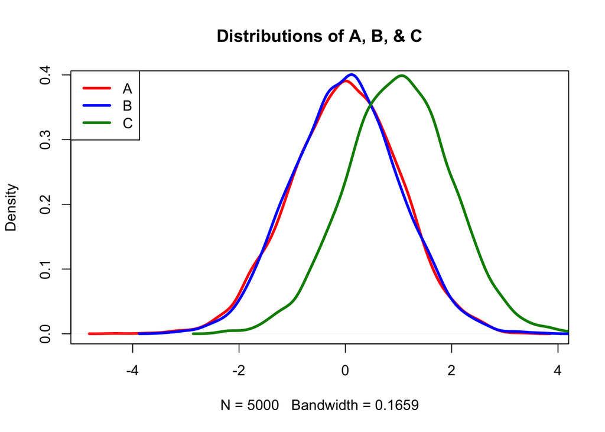

One can test for differences in these distributions in either a) their means using t-tests, or b) their entire distributions using ks-tests

```r
# Basic Call
t.test(x=, y=, var.equal=, conf.level=, formula=)
ks.test(x=, y=)
```

```r
t.test(x=a, y=b) # No difference in means
```

```
    Welch Two Sample t-test

data:  a and b
t = -0.4028, df = 9996.297, p-value = 0.6871
alternative hypothesis: true difference in means is not equal to 0
95 percent confidence interval:
 -0.04752875  0.03132462
sample estimates:
   mean of x    mean of y
-0.003444856  0.004657208
```

```r
t.test(x=a, y=c) # Difference in means
```

```
    Welch Two Sample t-test

data:  a and c
t = -50.1336, df = 9993.815, p-value < 2.2e-16
alternative hypothesis: true difference in means is not equal to 0
95 percent confidence interval:
 -1.0439830 -0.9654164
sample estimates:
   mean of x    mean of y
-0.003444856  1.001254867
```

```r
ks.test(x=a, y=b) # No difference in distributions
```

```
    Two-sample Kolmogorov-Smirnov test

data:  a and b
D = 0.0124, p-value = 0.8367
alternative hypothesis: two-sided
```

```r
ks.test(x=a, y=c) # Difference in distributions
```

```
    Two-sample Kolmogorov-Smirnov test

data:  a and c
D = 0.3794, p-value < 2.2e-16
alternative hypothesis: two-sided
```

As a practical example, we can ask whether the airlines “UA” and “AA” have different mean arrival delays.

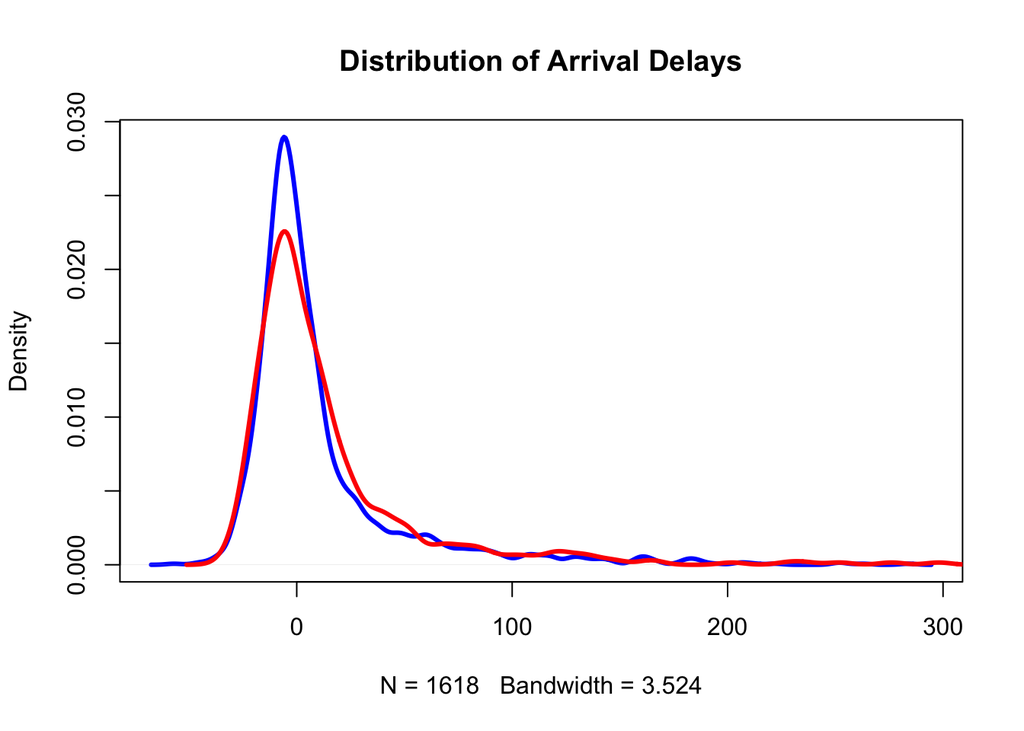

```r
plot(density(air$ArrDelay[air$UniqueCarrier=="UA"], na.rm = T), col="blue", lwd=3, main="Distribution of Arrival Delays")
lines(density(air$ArrDelay[air$UniqueCarrier=="AA"], na.rm = T), col="red", lwd=3)
```

```r
t.test(x = air$ArrDelay[air$UniqueCarrier=="UA"],air$ArrDelay[air$UniqueCarrier=="AA"])
```

```
    Welch Two Sample t-test

data:  air$ArrDelay[air$UniqueCarrier == "UA"] and air$ArrDelay[air$UniqueCarrier == "AA"]
t = -1.7219, df = 671.847, p-value = 0.08555
alternative hypothesis: true difference in means is not equal to 0
95 percent confidence interval:
 -8.2540460  0.5411187
sample estimates:
mean of x mean of y
 10.47033  14.32680
```

```r
ks.test(x = air$ArrDelay[air$UniqueCarrier=="UA"],air$ArrDelay[air$UniqueCarrier=="AA"])
```

```
    Two-sample Kolmogorov-Smirnov test

data:  air$ArrDelay[air$UniqueCarrier == "UA"] and air$ArrDelay[air$UniqueCarrier == "AA"]
D = 0.0726, p-value = 0.04608
alternative hypothesis: two-sided
```

### Inference/Regression

Running regressions in R is extremely simple, very straightforwd (though doing things with standard errors requires a little extra work). Most basic, catch-all regression function in R is *glm*, which fits a generalized linear model with your choice of family/link function (gaussian, logit, poisson, etc.)

*lm* is just a standard linear regression (equivalent to glm with family=gaussian(link=“identity”))

The basic glm call looks something like this:

```r
glm(formula=y~x1+x2+x3+..., family=familyname(link="linkname"), data=)
```

There are a bunch of families and links to use (help(family) for a full list), but some essentials are **binomial(link = “logit”)**, **gaussian(link = “identity”)**, and **poisson(link = “log”)**

Example: suppose we want to regress explain the variation in departure delays. A typical glm call would be something like this:

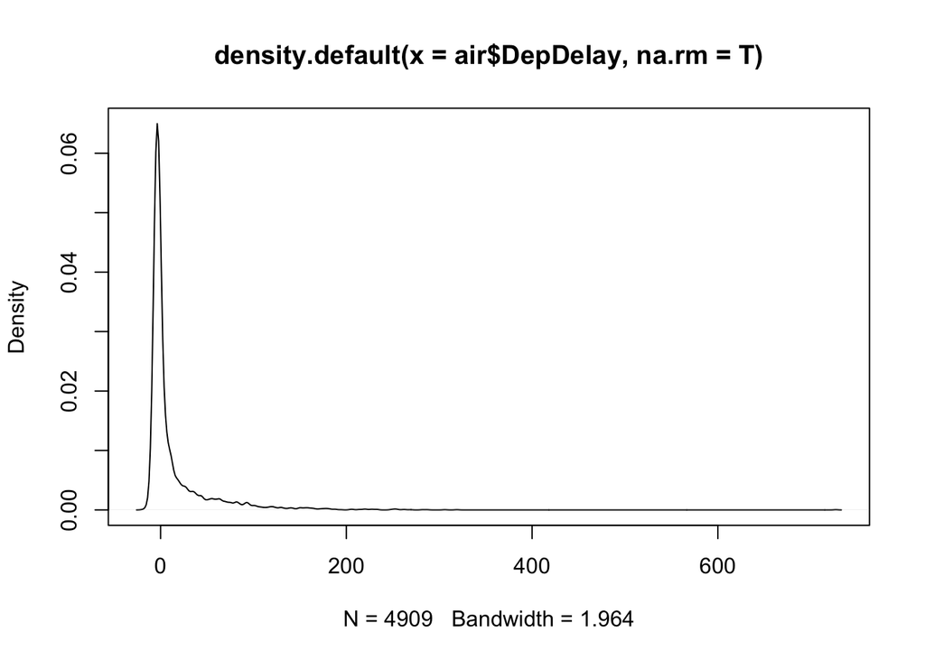

```r
# Departure delays appear highly right-skewed; use inverse hyperbolic sine transformation
plot(density(air$DepDelay, na.rm=T))
```

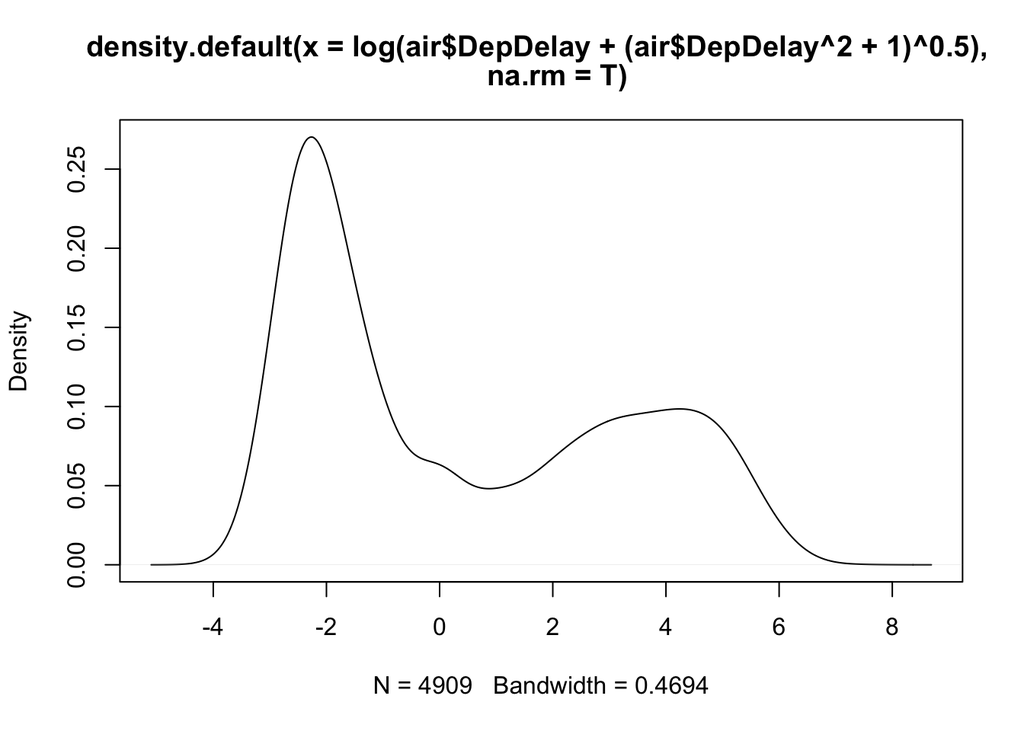

```r
plot(density(log(air$DepDelay+(air$DepDelay^2+1)^0.5), na.rm=T))
```

```r
air$logDepDelay<-log(air$DepDelay+(air$DepDelay^2+1)^0.5)
reg<-glm(formula = logDepDelay~Year+Month+DayOfWeek+CRSDepTime+Distance+UniqueCarrier, data = air)
reg
```

```
Call:  glm(formula = logDepDelay ~ Year + Month + DayOfWeek + CRSDepTime +
    Distance + UniqueCarrier, data = air)

Coefficients:
    (Intercept)             Year            Month        DayOfWeek
     -2.994e+02        1.488e-01        2.848e-03        2.589e-02
     CRSDepTime         Distance  UniqueCarrierAS  UniqueCarrierB6
      6.484e-04        2.847e-04       -1.536e-01       -1.091e+00
UniqueCarrierCO  UniqueCarrierDH  UniqueCarrierDL  UniqueCarrierEV
     -7.309e-01       -8.680e-01       -3.749e-01       -8.987e-01
UniqueCarrierF9  UniqueCarrierFL  UniqueCarrierHA  UniqueCarrierHP
     -1.895e-01       -6.907e-01       -1.503e+00       -8.641e-02
UniqueCarrierMQ  UniqueCarrierNW  UniqueCarrierOO  UniqueCarrierTZ
     -2.066e-01       -1.142e+00        3.864e-01       -1.288e+00
UniqueCarrierUA  UniqueCarrierUS  UniqueCarrierWN  UniqueCarrierXE
     -2.070e-01       -3.904e-01       -1.210e-01        1.399e-01
UniqueCarrierYV
      7.201e-02

Degrees of Freedom: 4908 Total (i.e. Null);  4884 Residual
  (91 observations deleted due to missingness)
Null Deviance:      39980
Residual Deviance: 38800    AIC: 24130
```

When we store this regression in an object, we get access to several items of interest

```r
# View objects contained in the regression output
objects(reg)
```

```
 [1] "aic"               "boundary"          "call"
 [4] "coefficients"      "contrasts"         "control"
 [7] "converged"         "data"              "deviance"
[10] "df.null"           "df.residual"       "effects"
[13] "family"            "fitted.values"     "formula"
[16] "iter"              "linear.predictors" "method"
[19] "model"             "na.action"         "null.deviance"
[22] "offset"            "prior.weights"     "qr"
[25] "R"                 "rank"              "residuals"
[28] "terms"             "weights"           "xlevels"
[31] "y"
```

```r
# Examine regression coefficients
reg$coefficients
```

```
    (Intercept)            Year           Month       DayOfWeek
  -2.994187e+02    1.487927e-01    2.848085e-03    2.588587e-02
     CRSDepTime        Distance UniqueCarrierAS UniqueCarrierB6
   6.483665e-04    2.846752e-04   -1.536028e-01   -1.091495e+00
UniqueCarrierCO UniqueCarrierDH UniqueCarrierDL UniqueCarrierEV
  -7.309102e-01   -8.679750e-01   -3.748549e-01   -8.987421e-01
UniqueCarrierF9 UniqueCarrierFL UniqueCarrierHA UniqueCarrierHP
  -1.895424e-01   -6.906573e-01   -1.503232e+00   -8.640528e-02
UniqueCarrierMQ UniqueCarrierNW UniqueCarrierOO UniqueCarrierTZ
  -2.065644e-01   -1.141629e+00    3.863828e-01   -1.288342e+00
UniqueCarrierUA UniqueCarrierUS UniqueCarrierWN UniqueCarrierXE
  -2.070397e-01   -3.903632e-01   -1.210144e-01    1.398511e-01
UniqueCarrierYV
   7.201343e-02
```

```r
# Examine regression DoF
reg$df.residual
```

```
[1] 4884
```

```r
# Examine regression fit (AIC)
reg$aic
```

```
[1] 24131.65
```

R has a helpful summary method for regression objects

```r
summary(reg)
```

```
Call:
glm(formula = logDepDelay ~ Year + Month + DayOfWeek + CRSDepTime +
    Distance + UniqueCarrier, data = air)

Deviance Residuals:
   Min      1Q  Median      3Q     Max
-4.689  -2.423  -1.024   2.636   8.117

Coefficients:
                  Estimate Std. Error t value Pr(>|t|)
(Intercept)     -2.994e+02  7.429e+01  -4.030 5.65e-05 ***
Year             1.488e-01  3.702e-02   4.019 5.92e-05 ***
Month            2.848e-03  1.188e-02   0.240  0.81052
DayOfWeek        2.589e-02  2.004e-02   1.292  0.19658
CRSDepTime       6.484e-04  8.074e-05   8.031 1.21e-15 ***
Distance         2.847e-04  6.152e-05   4.627 3.80e-06 ***
UniqueCarrierAS -1.536e-01  2.586e-01  -0.594  0.55251
UniqueCarrierB6 -1.091e+00  4.683e-01  -2.331  0.01980 *
UniqueCarrierCO -7.309e-01  2.596e-01  -2.816  0.00488 **
UniqueCarrierDH -8.680e-01  1.636e+00  -0.531  0.59571
UniqueCarrierDL -3.749e-01  2.318e-01  -1.617  0.10596
UniqueCarrierEV -8.987e-01  1.418e+00  -0.634  0.52631
UniqueCarrierF9 -1.895e-01  3.569e-01  -0.531  0.59536
UniqueCarrierFL -6.907e-01  5.595e-01  -1.235  0.21707
UniqueCarrierHA -1.503e+00  7.190e-01  -2.091  0.03661 *
UniqueCarrierHP -8.641e-02  4.591e-01  -0.188  0.85072
UniqueCarrierMQ -2.066e-01  3.824e-01  -0.540  0.58914
UniqueCarrierNW -1.142e+00  2.856e-01  -3.998 6.49e-05 ***
UniqueCarrierOO  3.864e-01  1.742e-01   2.218  0.02659 *
UniqueCarrierTZ -1.288e+00  5.708e-01  -2.257  0.02405 *
UniqueCarrierUA -2.070e-01  1.512e-01  -1.369  0.17096
UniqueCarrierUS -3.904e-01  2.275e-01  -1.716  0.08625 .
UniqueCarrierWN -1.210e-01  2.747e-01  -0.441  0.65958
UniqueCarrierXE  1.399e-01  7.022e-01   0.199  0.84213
UniqueCarrierYV  7.201e-02  1.634e+00   0.044  0.96485
---
Signif. codes:  0 '***' 0.001 '**' 0.01 '*' 0.05 '.' 0.1 ' ' 1

(Dispersion parameter for gaussian family taken to be 7.944125)

    Null deviance: 39985  on 4908  degrees of freedom
Residual deviance: 38799  on 4884  degrees of freedom
  (91 observations deleted due to missingness)
AIC: 24132

Number of Fisher Scoring iterations: 2
```

Can also extract useful things from the summary object (like a matrix of coefficient estimates…)

```r
# Store summary method results
sum.reg<-summary(reg)
# View summary method results objects
objects(sum.reg)
```

```
 [1] "aic"            "aliased"        "call"           "coefficients"
 [5] "contrasts"      "cov.scaled"     "cov.unscaled"   "deviance"
 [9] "deviance.resid" "df"             "df.null"        "df.residual"
[13] "dispersion"     "family"         "iter"           "na.action"
[17] "null.deviance"  "terms"
```

```r
# View table of coefficients
sum.reg$coefficients
```

```
                     Estimate   Std. Error     t value     Pr(>|t|)
(Intercept)     -2.994187e+02 7.428956e+01 -4.03042801 5.652267e-05
Year             1.487927e-01 3.701921e-02  4.01933628 5.924122e-05
Month            2.848085e-03 1.187828e-02  0.23977252 8.105167e-01
DayOfWeek        2.588587e-02 2.004254e-02  1.29154641 1.965754e-01
CRSDepTime       6.483665e-04 8.073699e-05  8.03059927 1.205706e-15
Distance         2.846752e-04 6.152160e-05  4.62724075 3.801591e-06
UniqueCarrierAS -1.536028e-01 2.585722e-01 -0.59404216 5.525114e-01
UniqueCarrierB6 -1.091495e+00 4.682810e-01 -2.33085388 1.980156e-02
UniqueCarrierCO -7.309102e-01 2.595657e-01 -2.81589645 4.883639e-03
UniqueCarrierDH -8.679750e-01 1.635795e+00 -0.53061349 5.957108e-01
UniqueCarrierDL -3.748549e-01 2.318296e-01 -1.61694150 1.059555e-01
UniqueCarrierEV -8.987421e-01 1.418248e+00 -0.63369905 5.263069e-01
UniqueCarrierF9 -1.895424e-01 3.568769e-01 -0.53111413 5.953638e-01
UniqueCarrierFL -6.906573e-01 5.594507e-01 -1.23452746 2.170658e-01
UniqueCarrierHA -1.503232e+00 7.190301e-01 -2.09063899 3.661201e-02
UniqueCarrierHP -8.640528e-02 4.590885e-01 -0.18821048 8.507195e-01
UniqueCarrierMQ -2.065644e-01 3.824428e-01 -0.54011839 5.891400e-01
UniqueCarrierNW -1.141629e+00 2.855786e-01 -3.99760005 6.493187e-05
UniqueCarrierOO  3.863828e-01 1.741881e-01  2.21819341 2.658747e-02
UniqueCarrierTZ -1.288342e+00 5.708317e-01 -2.25695568 2.405485e-02
UniqueCarrierUA -2.070397e-01 1.511985e-01 -1.36932399 1.709610e-01
UniqueCarrierUS -3.903632e-01 2.275048e-01 -1.71584584 8.625368e-02
UniqueCarrierWN -1.210144e-01 2.747052e-01 -0.44052461 6.595767e-01
UniqueCarrierXE  1.398511e-01 7.021512e-01  0.19917523 8.421340e-01
UniqueCarrierYV  7.201343e-02 1.634248e+00  0.04406518 9.648542e-01
```

Note that, in our results, R has broken up our variables into their different factor levels (as it will do whenever your regressors have factor levels). If your data aren’t factorized, you can tell glm to factorize a variable (i.e. create dummy variables on the fly) by writing

```r
glm(formula=y~x1+x2+factor(x3), family=family(link="link"), data=)
```

There are also some useful shortcuts for regressing on interaction terms:

**x1:x2** interacts all terms in x1 with all terms in x2 (either by multiplication or dummy expansion)

```r
summary(glm(formula = logDepDelay~Year+Month+DayOfWeek+CRSDepTime:Distance+UniqueCarrier,
            data = air))
```

```
Call:
glm(formula = logDepDelay ~ Year + Month + DayOfWeek + CRSDepTime:Distance +
    UniqueCarrier, data = air)

Deviance Residuals:
   Min      1Q  Median      3Q     Max
-4.643  -2.445  -1.044   2.644   8.089

Coefficients:
                      Estimate Std. Error t value Pr(>|t|)
(Intercept)         -2.890e+02  7.448e+01  -3.880 0.000106 ***
Year                 1.440e-01  3.711e-02   3.879 0.000106 ***
Month                2.710e-03  1.191e-02   0.227 0.820047
DayOfWeek            2.364e-02  2.009e-02   1.176 0.239544
UniqueCarrierAS      1.719e-02  2.534e-01   0.068 0.945917
UniqueCarrierB6     -1.134e+00  4.699e-01  -2.413 0.015865 *
UniqueCarrierCO     -7.917e-01  2.591e-01  -3.056 0.002257 **
UniqueCarrierDH     -8.956e-01  1.641e+00  -0.546 0.585295
UniqueCarrierDL     -3.991e-01  2.324e-01  -1.717 0.086088 .
UniqueCarrierEV     -1.174e+00  1.421e+00  -0.826 0.408757
UniqueCarrierF9     -1.642e-01  3.564e-01  -0.461 0.644977
UniqueCarrierFL     -6.819e-01  5.614e-01  -1.215 0.224537
UniqueCarrierHA     -1.549e+00  7.189e-01  -2.154 0.031262 *
UniqueCarrierHP      3.561e-03  4.576e-01   0.008 0.993791
UniqueCarrierMQ     -1.719e-01  3.795e-01  -0.453 0.650569
UniqueCarrierNW     -1.187e+00  2.862e-01  -4.150 3.39e-05 ***
UniqueCarrierOO      5.285e-01  1.638e-01   3.227 0.001258 **
UniqueCarrierTZ     -1.303e+00  5.722e-01  -2.277 0.022827 *
UniqueCarrierUA     -1.555e-01  1.504e-01  -1.035 0.300952
UniqueCarrierUS     -3.709e-01  2.275e-01  -1.631 0.103037
UniqueCarrierWN     -3.516e-02  2.715e-01  -0.130 0.896954
UniqueCarrierXE      1.655e-01  7.018e-01   0.236 0.813586
UniqueCarrierYV      5.000e-02  1.638e+00   0.031 0.975653
CRSDepTime:Distance  2.615e-07  3.484e-08   7.507 7.12e-14 ***
---
Signif. codes:  0 '***' 0.001 '**' 0.01 '*' 0.05 '.' 0.1 ' ' 1

(Dispersion parameter for gaussian family taken to be 7.989363)

    Null deviance: 39985  on 4908  degrees of freedom
Residual deviance: 39028  on 4885  degrees of freedom
  (91 observations deleted due to missingness)
AIC: 24159

Number of Fisher Scoring iterations: 2
```

**x1//*x2** produces the cross of x1 and x2, or x1+x2+x1:x2

```r
summary(glm(formula = logDepDelay~Year+Month+DayOfWeek+CRSDepTime*Distance+UniqueCarrier,
            data = air))
```

```
Call:
glm(formula = logDepDelay ~ Year + Month + DayOfWeek + CRSDepTime *
    Distance + UniqueCarrier, data = air)

Deviance Residuals:
   Min      1Q  Median      3Q     Max
-4.689  -2.423  -1.025   2.636   8.118

Coefficients:
                      Estimate Std. Error t value Pr(>|t|)
(Intercept)         -2.994e+02  7.430e+01  -4.030 5.66e-05 ***
Year                 1.488e-01  3.702e-02   4.019 5.93e-05 ***
Month                2.851e-03  1.188e-02   0.240  0.81038
DayOfWeek            2.588e-02  2.004e-02   1.291  0.19664
CRSDepTime           6.452e-04  1.291e-04   4.999 5.97e-07 ***
Distance             2.809e-04  1.353e-04   2.077  0.03788 *
UniqueCarrierAS     -1.535e-01  2.586e-01  -0.594  0.55282
UniqueCarrierB6     -1.092e+00  4.687e-01  -2.330  0.01984 *
UniqueCarrierCO     -7.307e-01  2.597e-01  -2.814  0.00492 **
UniqueCarrierDH     -8.701e-01  1.637e+00  -0.531  0.59517
UniqueCarrierDL     -3.751e-01  2.320e-01  -1.617  0.10595
UniqueCarrierEV     -9.000e-01  1.419e+00  -0.634  0.52593
UniqueCarrierF9     -1.897e-01  3.570e-01  -0.531  0.59510
UniqueCarrierFL     -6.913e-01  5.599e-01  -1.235  0.21700
UniqueCarrierHA     -1.502e+00  7.212e-01  -2.082  0.03740 *
UniqueCarrierHP     -8.652e-02  4.591e-01  -0.188  0.85055
UniqueCarrierMQ     -2.070e-01  3.827e-01  -0.541  0.58864
UniqueCarrierNW     -1.142e+00  2.856e-01  -3.997 6.50e-05 ***
UniqueCarrierOO      3.864e-01  1.742e-01   2.218  0.02662 *
UniqueCarrierTZ     -1.288e+00  5.709e-01  -2.257  0.02407 *
UniqueCarrierUA     -2.071e-01  1.512e-01  -1.369  0.17096
UniqueCarrierUS     -3.906e-01  2.276e-01  -1.716  0.08624 .
UniqueCarrierWN     -1.212e-01  2.748e-01  -0.441  0.65928
UniqueCarrierXE      1.393e-01  7.024e-01   0.198  0.84277
UniqueCarrierYV      7.157e-02  1.634e+00   0.044  0.96508
CRSDepTime:Distance  2.758e-09  8.762e-08   0.031  0.97489
---
Signif. codes:  0 '***' 0.001 '**' 0.01 '*' 0.05 '.' 0.1 ' ' 1

(Dispersion parameter for gaussian family taken to be 7.94575)

    Null deviance: 39985  on 4908  degrees of freedom
Residual deviance: 38799  on 4883  degrees of freedom
  (91 observations deleted due to missingness)
AIC: 24134

Number of Fisher Scoring iterations: 2
```